# Remote Sensing Tutorial 1-3

Matthew Ng, Maxim Chernetskiy, Andrew MacLachlan

7/22/2019

# Tutorial 1: Introduction to Raster Data and Analysis

## Learning Objectives

1. What is raster data?
2. Where to get raster data?
3. Basic information about your datasets
4. Mathematical applications to each dataset

## Learning Outcomes

1. Load and conduct appropriate pre-processing methods to begin raster analysis.
2. Identify how raster data is structured, and derive basic information from composites of raster layers.
3. Grasp the fundamental numerical approaches that can be applied to raster data for quick visualisation of specific properties.
4. Reproduce these methodologies to other datasets.

## Data

- The raster data that we will be using today is of the Manchester metropolitan area taken from the United States Geological Survey Landsat 8 OLI/TIR satellite.
- There are a total of 11 bands, saved in `.TIFF` format. Each sensor (band) captures different parts of the electromagnetic spectrum; and, what is captured heavily depends on what is reflected by the objects on the surface of the earth.
- The data is presented in a 30m by 30m resolution for most bands; except, in Band 8, which is called the panchromatic band represented in 15m by 15m cells; and, Band 10 and Band 11, which cover a larger scale of 100m x 100m.
- The table below gives the wavelengths and resolutions of the various bands that make up a Landsat 8 image. We will refer back to this table in the following exercises over the following tutorials.

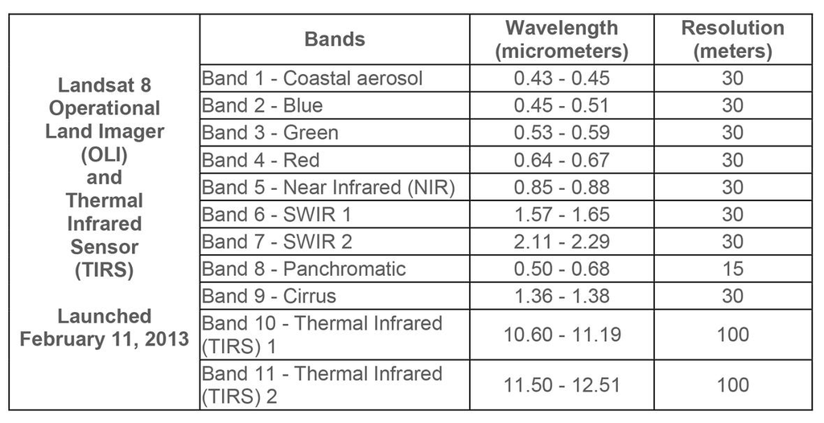

## Required libraries

These are all the required libraries required for the next three remote-sensing tutorials.

```r
library(sp)
library(RColorBrewer)
library(lattice)
library(latticeExtra)
library(raster)
library(rgeos)
library(rgdal)
library(rasterVis)
library(ggplot2)
library(RStoolbox)
```

# Setup Environment

## Getting our data

There are several places that remote sensing data can be obtained. Depending on your coverage requirements, they may be available in various formats, resolutions, and sources.

For images in the USGS Landsat programme, my favourite repositories are:

- Landsat Look: https://landlook.usgs.gov/viewer.html
- Earth Explorer: https://earthexplorer.usgs.gov/
- GloVis: https://glovis.usgs.gov

You will need to create an account download the data should you wish to extend this tutorial to another area.

N.B. Bearing in mind the intended study area, these files can quickly become very large, and your workflow should be adapated to this.

For the purposes of this tutorial, the data we are going be used is available here:

**https://drive.google.com/open?id=1NPUAqw1VJ6_jUNfp7srtmdMg4Oh10CWr**

Go ahead and download this folder and save this into your local machine

```r
# Let's now set up our environment on R
setwd("C:/Users/mattk/OneDrive/Desktop/rs")

# Load the Manchester shapefile
manchester_shape <- readOGR('C:/Users/mattk/OneDrive/Desktop/rs/manchester_boundary.shp')
```

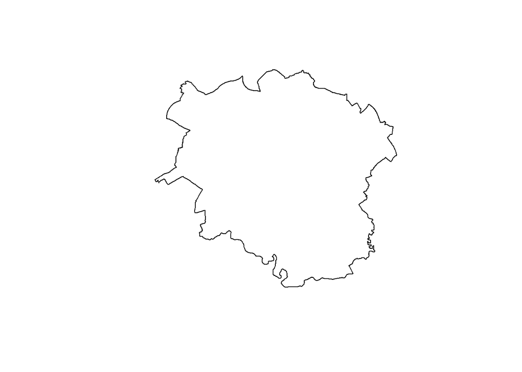

```r
plot(manchester_shape)
```

```r
# Load our Landsat Data. We will be using Landsat 8's Band 1 to 8 in this practical.

manc_files <- paste0("Raw Landsat/LC08_L1TP_203023_20190513_20190521_01_T1_B", 1:8, ".tif")

# There is however an error with this dataset in that the panchromatic Band 8 does not fully align with the extent of the other raster layers. This prevents us from stacking all 8 bands into a single composite, as shown:

manchester <- stack(manc_files)
```

```
## Error in compareRaster(rasters): different extent
```

# Preprocessing

## Extent rectification

The error with extents is quite common in RS analysis. There are several ways to go about to rectify this. One method is to sharpen all bands with Band 8. The other method is to resample Band 8 with the other bands used in our composite.

Both ways take a little bit of time, but they are to ensure consistency throughout.

We may now want to think about the pros and cons of one method over the other in your own research.

The panchromatic sharpening can be used with the `panSharpen()` function in the `RStoolbox` library.

In this tutorial, we are going to be using the `resample` method with the code below.